# Synopsis Generator Notebook

Introduction

1. Introduction
2. Librairies, Config & APIs
3. Scrapping

Chapter 1 : Data Analysis & Visualization

1. Section 1.1
2. Section 1.2
3. Section 1.3

Chapter 2 : Models

1. Section 2.1 : Classification
2. Section 2.2 : Generation
   1. Section 2.2.1 : Generation Synopsis
   2. Section 2.2.2 : Generation Poster

Chapter 3 : App

1. Section 3.1 : All
2. Section 3.2 : TV Shows
3. Section 3.3 : Movies

### Introduction & Librairies

#### Introduction

##### What is this ?

- This is a potential creative app that uses generative models as a playground for users to generate overview of movies & tv show. It's mostly an app to learn about using and fine-tuning HuggingFace models like BERT & GPT-2.

##### What is this notebook ? Wouldn't python script be easier ?

- This is the Notebook used to make all the preparations to make a python backend for the app. Using a notebook makes it easier to experiment and also for the exploratory data analysis that'll be first made to explore the data we have to work with. Once experimentation is done, we can extract the code and put it in a lib that will be pushed into a git repository and used in the final demo & app.

##### Why this app/idea ?

- Because it enables me to learn more about how Hugging Face is used to produce models used in production. Hugging Face has become the face of NLP models and being able to use a pre-existing model and fine-tune it to fit a need is a skill that I wanted to train on.

#### Librairies, Config & APIs

This is where all the import & config happens.

The biggest import are :

| Librairies | What it's used for |
| --- | --- |
| Pandas & Numpy | Process & Handling of the data |
| Pyplot, Plotly & Seaborn | Visualize the data |
| Tensorflow & Keras | Deep Learning backend & framework |
| Transformers & Diffusers | Deep Learning NLP models |

We also need to config the API key for TMDB to be able to scrap the database and an HF token to be able to push fine-tuned model to the Hugging Face Hub.

```python
import os
import glob
import json
import requests
import calendar

import pandas as pd
import numpy as np

import matplotlib.pyplot as plt
import seaborn as sns
import plotly.express as px
import plotly.graph_objects as go

import tensorflow as tf

from transformers import AutoTokenizer, create_optimizer, AdamWeightDecay, DataCollatorWithPadding, TFAutoModelForSequenceClassification, TFAutoModelForCausalLM

from transformers.keras_callbacks import PushToHubCallback, KerasMetricCallback
from keras.callbacks import TensorBoard
import evaluate

from datasets import Dataset

from diffusers import DiffusionPipeline, LCMScheduler

HF_TOKEN = os.environ['HF_TOKEN']
API_KEY = os.environ["TMDB_API_KEY"]
API_VERSION = 3
API_BASE_URL = f"https://api.themoviedb.org/{API_VERSION}"
RANDOM_STATE = 21
```

#### Scrapping TMDB

Using TMDB's API, we can scrape the database using a function that will cycle through every movies & tv shows id to get the details. Unfortunatly there's no way around this except choosing another database and TMDB doesn't offer images of their database, offering only an API service limited to 40 requests per second. This makes the scrapping a very heavy process. You can get the script here

```
from scripts.scrapper import scrapper_tmdb

## Movies
scrapper_tmdb('./data/jsons/04_11_2023/ids/movie_ids_04_11_2023.json', './data/jsons/04_11_2023/movie', 10, 'movie', API_BASE_URL, API_KEY)

## TV Shows
scrapper_tmdb('./data/jsons/04_11_2023/ids/tv_series_ids_04_11_2023.json', './data/jsons/04_11_2023/tv', 10, 'tv', API_BASE_URL, API_KEY)
```

### Chapter 1 : Data Analysis & Vizualisation

#### Section 1.1 : Building the dataset

After using the scrapper, we're left with multiple json that we can load with pandas using the function defined below

```python
def get_json(file):
    with open(file) as f:
        data = json.load(f)
    return data

def get_df_from_json_folder(filepath, cols=[]):
    json_pattern = os.path.join(filepath, '*.json')
    list_of_files = glob.glob(json_pattern)

    list_of_files.sort(key=lambda x: int(
        os.path.splitext(x)[0].split('-')[1]
    ))

    dfs = [pd.DataFrame(get_json(file)).T for file in list_of_files]

    return pd.concat(dfs, ignore_index=True)[cols] if cols else pd.concat(dfs, ignore_index=True)
```

```python
series_columns = ['backdrop_path', 'created_by', 'episode_run_time', 'first_air_date', 'genres', 'in_production', 'languages', 'last_air_date', 'last_episode_to_air', 'name', 'networks', 'number_of_episodes', 'number_of_seasons', 'origin_country', 'original_language', 'original_name', 'overview', 'popularity', 'production_companies', 'production_countries', 'seasons', 'spoken_languages', 'status', 'tagline', 'type', 'vote_average', 'vote_count']

movies_columns = ['backdrop_path', 'belongs_to_collection', 'budget', 'genres', 'homepage', 'original_language', 'original_title', 'overview', 'popularity', 'poster_path', 'production_companies', 'production_countries', 'release_date', 'revenue', 'runtime', 'spoken_languages', 'status', 'tagline', 'title', 'vote_average', 'vote_count']

df_movies_raw = get_df_from_json_folder('./data/jsons/04_11_2023/movie', movies_columns)

df_series_raw = get_df_from_json_folder('./data/jsons/04_11_2023/tv', series_columns)
```

Preprocessing data for EDA, we start by filtering columns that aren't useful for data analysis and revealing where the NaNs values are.

```python
def preprocess_df(df_raw, col_list, col_process_list):
    result_df = df_raw[col_list].copy()
    result_df = result_df.mask(result_df == '').mask(result_df.map(str).eq('[]'))

    for col in col_process_list:
        result_df[col] = result_df[col].apply(lambda row : [dicts['name'] for dicts in row] if type(row) == list else row)

    return result_df
```

```python
movies_eda_columns = ['belongs_to_collection', 'budget', 'genres', 'homepage', 'original_language', 'original_title', 'overview', 'popularity', 'production_companies', 'production_countries', 'release_date', 'revenue', 'runtime', 'spoken_languages', 'status', 'tagline', 'title', 'vote_average', 'vote_count']

movies_cols_to_process = ['genres', 'production_companies', 'production_countries']

df_movies = preprocess_df(df_movies_raw, movies_eda_columns, movies_cols_to_process)

df_movies['belongs_to_collection'] = df_movies['belongs_to_collection'].fillna(value=np.nan).apply(lambda row: row['name'] if type(row) == dict else row)
```

```python
series_eda_columns = ['created_by', 'episode_run_time', 'first_air_date', 'genres', 'in_production', 'languages', 'last_air_date', 'name', 'networks', 'number_of_episodes', 'number_of_seasons', 'origin_country', 'original_language', 'original_name', 'overview', 'popularity', 'production_companies', 'production_countries', 'seasons', 'spoken_languages', 'status', 'tagline', 'type', 'vote_average', 'vote_count']

series_cols_to_process = ['created_by', 'genres', 'networks', 'production_companies', 'production_countries', 'seasons']

df_series = preprocess_df(df_series_raw, series_eda_columns, series_cols_to_process)
```

```python
for df in [df_movies, df_series]:
    df['spoken_languages'] = df['spoken_languages'].apply(lambda row: [dicts['english_name'] for dicts in row] if type(row) == list else row)
```

We can now look at the data once it's been preprocessed

```python
print(df_movies.shape)
df_movies.head(2)
```

```
(859971, 19)
```

|  | belongs_to_collection | budget | genres | homepage | original_language | original_title | overview | popularity | production_companies | production_countries | release_date | revenue | runtime | spoken_languages | status | tagline | title | vote_average | vote_count |
| --- | --- | --- | --- | --- | --- | --- | --- | --- | --- | --- | --- | --- | --- | --- | --- | --- | --- | --- | --- |
| 0 | Blondie Collection | 0 | [Comedy, Family] | NaN | en | Blondie | Blondie and Dagwood are about to celebrate the... | 2.5 | [Columbia Pictures] | [United States of America] | 1938-11-30 | 0 | 70 | [English] | Released | The favorite comic strip of millions at last o... | Blondie | 7.2 | 7 |
| 1 | NaN | 0 | [Adventure] | NaN | de | Der Mann ohne Namen | NaN | 1.091 | NaN | [Germany] | 1921-01-01 | 0 | 420 | NaN | Released | NaN | Peter Voss, Thief of Millions | 0.0 | 0 |

```python
print(df_series.shape)
df_series.head(2)
```

```
(158626, 25)
```

|  | created_by | episode_run_time | first_air_date | genres | in_production | languages | last_air_date | name | networks | number_of_episodes | ... | popularity | production_companies | production_countries | seasons | spoken_languages | status | tagline | type | vote_average | vote_count |
| --- | --- | --- | --- | --- | --- | --- | --- | --- | --- | --- | --- | --- | --- | --- | --- | --- | --- | --- | --- | --- | --- |
| 0 | NaN | [60] | 2004-01-12 | [Drama] | False | [ja] | 2004-03-22 | Pride | [Fuji TV] | 11 | ... | 18.171 | NaN | [Japan] | [Season 1] | [Japanese] | Ended | NaN | Scripted | 8.2 | 13 |
| 1 | [Kevin Smith, Scott Mosier, David Mandel] | [22] | 2000-05-31 | [Animation, Comedy] | False | [en] | 2002-12-22 | Clerks | [ABC, Comedy Central] | 6 | ... | 31.201 | [Touchstone Television, View Askew Productions... | [United States of America] | [Specials, Season 1] | [English] | Canceled | NaN | Scripted | 7.012 | 86 |

2 rows × 25 columns

Now one important thing to look for is NaN values, we used the preprocessing step to highlight NaNs from void values (like empty lists or strings) so we can visualize them in a proper way, we can for that use a barchart or a heatmap

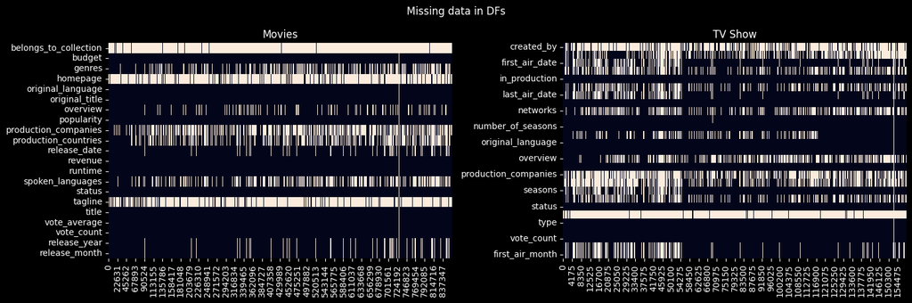

```python
nan_plot_dict = {
    "Movies" : df_movies.isna().T,
    "TV Show" : df_series.isna().T
    }

plt.subplots(figsize=(15,5))
plt.axis('off')
plt.suptitle('Missing data in DFs')
index = 1
for k,v in nan_plot_dict.items():
    plt.subplot(1,2,index)
    plt.title(k)
    sns.heatmap(v, cbar=False)
    index += 1
plt.tight_layout()
plt.savefig('./viz/nan_heatmap.png')
```

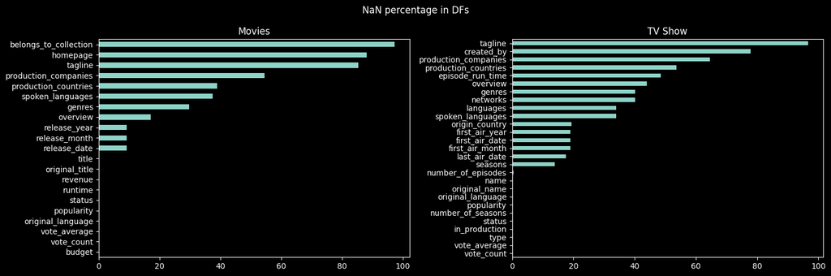

```python
nan_percentage_dict = {
    "Movies" : df_movies.isna().sum().sort_values(ascending=True) / len(df_movies) * 100,
    "TV Show" : df_series.isna().sum().sort_values(ascending=True) / len(df_series) * 100
    }

plt.subplots(figsize=(15,5))
plt.axis('off')
plt.suptitle('NaN percentage in DFs')
index = 1
for k,v in nan_percentage_dict.items():
    plt.subplot(1,2,index)
    plt.title(k)
    v.plot(kind='barh')
    index += 1
plt.tight_layout()
plt.savefig('./viz/nan_percent.png')
```

Now we can see that some columns have a lot of missing data. What we're interested in for generating overview & classifying genres are the `overview` & `genres` features. We're missing a lot of overview & genres in TV show and a little bit less overview are missing in movies. We can therefore see if we can train a model to infer those missing genres since trying to generate convincing overview based on title & genres seems a bit too difficult.

We can now try to have some general visualization of the data like the language

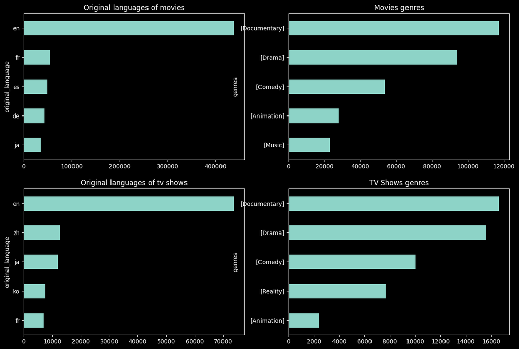

```python
plot_dict_movies = {
    "Original languages of movies" :
    df_movies['original_language'].value_counts().head().sort_values(ascending=True),
    "Movies genres" :
    df_movies['genres'].value_counts().head().sort_values(ascending=True),
    "Original languages of tv shows" :
    df_series['original_language'].value_counts().head().sort_values(ascending=True),
    "TV Shows genres" :
    df_series['genres'].value_counts().head().sort_values(ascending=True)
}

plt.subplots(figsize=(15,10))
plt.axis('off')
index = 1
for key, value in plot_dict_movies.items():
    plt.subplot(2,2, index)
    plt.title(key)
    value.plot(kind='barh')
    index += 1
plt.savefig('./viz/languages_genres.png')
```

```python
df_movies['release_date'] = pd.to_datetime(df_movies['release_date'])
df_series['first_air_date'] = pd.to_datetime(df_series['first_air_date'], errors='coerce')

df_movies['release_year'] = df_movies['release_date'].dt.year
df_movies['release_month'] = df_movies['release_date'].dt.month

df_series['first_air_year'] = df_series['first_air_date'].dt.year
df_series['first_air_month'] = df_series['first_air_date'].dt.month

print('TV Shows Air Date NaNs :', (df_series['first_air_date'].dt.year).isna().sum(), '\nMovies Air Date NaNs :', (df_movies['release_date'].dt.year).isna().sum())
```

```
TV Shows Air Date NaNs : 30083
Movies Air Date NaNs : 79628
```

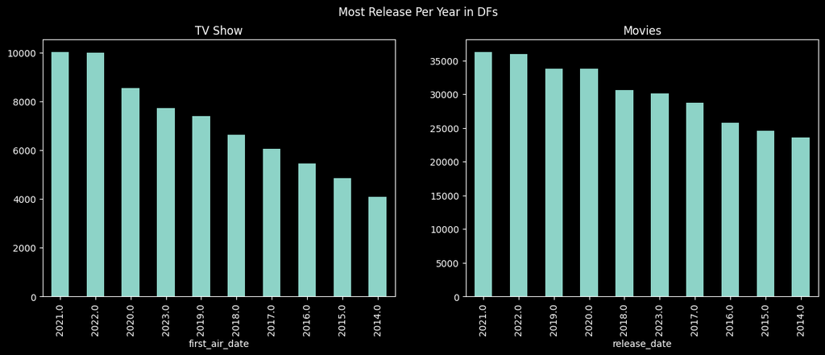

```python
plot_dict = {
    "TV Show" : df_series['first_air_date'].dt.year.value_counts().head(10),
    "Movies" : df_movies['release_date'].dt.year.value_counts().head(10)
    }

plt.subplots(figsize=(15,5))
plt.axis('off')
plt.suptitle('Most Release Per Year in DFs')
index = 1
for k,v in plot_dict.items():
    plt.subplot(1,2,index)
    plt.title(k)
    v.plot(kind='bar')
    index += 1
plt.savefig('./viz/release_year.png')
```

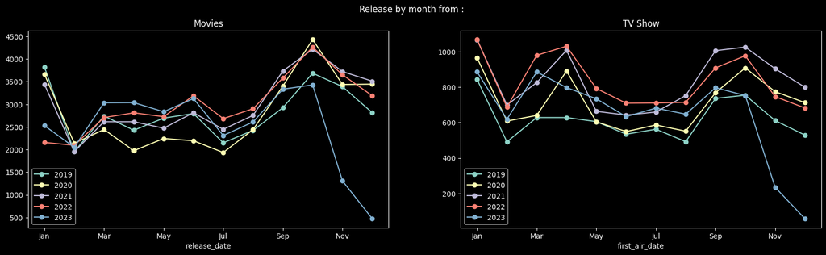

```python
start_year, end_year = 2019, 2023
year_list = [i for i in range(start_year, end_year + 1)]

plot_list = [[df_movies, 'release_date'], [df_series, 'first_air_date']]
title_list = ['Movies', 'TV Show']

def get_count_by_month(df, col, year):
    result = df[df[col].dt.year == year][col].dt.strftime("%b").value_counts().reindex(calendar.month_abbr[1:])
    return result

plt.subplots(figsize=(20,5))
plt.axis('off')
plt.suptitle('Release by month from :')
for index in range(2):
    plt.subplot(1, 2, index + 1)
    plt.title(title_list[index])
    for year in year_list:
        get_count_by_month(plot_list[index][0], plot_list[index][1], year).plot(marker='o')
    plt.legend(year_list[:])
plt.savefig('./viz/release_month.png')
```

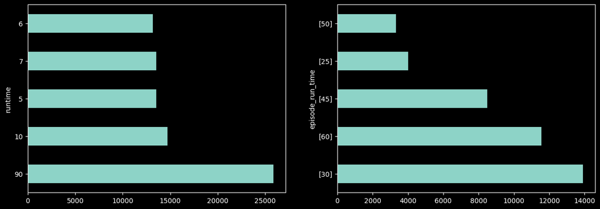

```python
plots = [df_movies[df_movies['runtime'] != 0]['runtime'],
df_series['episode_run_time']]

index = 1
plt.subplots(figsize=(15,5))
plt.axis('off')
for each in plots:
    plt.subplot(1,2,index)
    each.value_counts().head().plot(kind='barh')
    index += 1
plt.savefig('./viz/runtime.png')
```

```python
plot_dict = {
    "TV Show per countries" : df_series['production_countries'].explode().dropna().value_counts(),
    "Movies per countries" : df_movies['production_countries'].explode().dropna().value_counts()
    }

for title, plot in plot_dict.items():
    fig = go.Figure(data=go.Choropleth(locationmode='country names',  locations=plot.index.values, text=plot.index, z=plot.values, colorscale = 'Greys'))
    fig.update_layout(height=600, width=800, title_text=title,title_x=0.5)
    fig.show()
```

[interactive chart not shown]

### Chapter 2 : Models

The app has 2 principal functionnality that LLMs are able to help us with :

- Classification overviews into genre :
  - The user write an overview and the model tells us which genre this overview fits into
- Generation of overviews from genres & title :
  - The user write a title & select genres, the model give us an overview that fits the title & genres

#### Section 2.1 : Classification

```python
cols = ['genres', 'overview', 'title']

df_clf = pd.concat([
    df_movies[df_movies['overview'].notna()],
    df_series[df_series['overview'].notna()].rename(columns={'name' : 'title'})
    ], ignore_index=True)[cols].rename(columns={'genres' : 'label'})
```

```python
def filter_dominant_genres(genres_list):
    dominants_genres_list = ['Drama', 'Documentary', 'Comedy', 'Animation', 'Horror']
    if len(genres_list) > 1 and genres_list[0] in dominants_genres_list:
        processed_genres = [genre for genre in genres_list if genre not in dominants_genres_list]
        result = processed_genres[0] if len(processed_genres) > 0 else genres_list[0]
        return result
    else:
        return genres_list[0]
```

```python
replace_dict = {
    'Sci-Fi & Fantasy' : 'Science Fiction',
    'War & Politics' : 'History',
    'Musical' : 'Music',
    'News' : 'Reality',
    'Talk' : 'Reality',
    'Soap' : 'Drama',
    'Kids' : 'Family',
    'Action & Adventure' : 'Adventure',
    'War' : 'History'
}

df_clf['label'] = df_clf['label'].apply(lambda row : filter_dominant_genres(row) if type(row) == list else row).replace(replace_dict)

df_clf['text'] = df_clf['title'] + ' | ' + df_clf['overview']

candidates = df_clf['label'].value_counts().index.to_list()
```

```python
df_clf_to_train = df_clf[~df_clf['label'].isna()].copy()
df_clf_to_train.shape
```

```
(571212, 4)
```

```python
genre_index = df_clf_to_train['label'].factorize()[1]

df_clf_to_train['label'] = df_clf_to_train['label'].factorize()[0]

df_clf_to_train.head()
```

|  | label | overview | title | text |
| --- | --- | --- | --- | --- |
| 0 | 0 | Blondie and Dagwood are about to celebrate the... | Blondie | Blondie \| Blondie and Dagwood are about to cel... |
| 1 | 1 | Love at Twenty unites five directors from five... | Love at Twenty | Love at Twenty \| Love at Twenty unites five di... |
| 3 | 0 | Elmo is making a very, very super special surp... | Sesame Street: Elmo Loves You! | Sesame Street: Elmo Loves You! \| Elmo is makin... |
| 4 | 1 | After the coal mine he works at closes and his... | Ariel | Ariel \| After the coal mine he works at closes... |
| 5 | 1 | Nikander, a rubbish collector and would-be ent... | Shadows in Paradise | Shadows in Paradise \| Nikander, a rubbish coll... |

```python
tokenizer_clf = AutoTokenizer.from_pretrained("distilbert-base-uncased")

def tokenize_classifier(examples):
    return tokenizer_clf(examples["text"], truncation=True)

cols = ['text', 'label']

raw_datasets = Dataset.from_pandas(df_clf_to_train[cols], preserve_index=True).train_test_split(seed=RANDOM_STATE)

tokenized_dataset = raw_datasets.map(tokenize_classifier, batched=True, remove_columns=['__index_level_0__'])

data_collator = DataCollatorWithPadding(tokenizer=tokenizer_clf, return_tensors="tf")
```

```python
accuracy = evaluate.load("accuracy")

def compute_metrics(eval_pred):

    predictions, labels = eval_pred
    predictions = np.argmax(predictions, axis=1)

    return accuracy.compute(predictions=predictions, references=labels)
```

```python
n_label = len(genre_index)

id2label = {id:genre_index[id] for id in range(n_label)}
label2id = {genre_index[id]:id for id in range(n_label)}
```

```python
batch_size = 16
num_epochs = 3
batches_per_epoch = len(tokenized_dataset["train"]) // batch_size
total_train_steps = int(batches_per_epoch * num_epochs)
optimizer, schedule = create_optimizer(init_lr=2e-5, num_warmup_steps=0, num_train_steps=total_train_steps)

model_clf = TFAutoModelForSequenceClassification.from_pretrained(
    "distilbert-base-uncased", num_labels=n_label, id2label=id2label, label2id=label2id
)

tf_train_set = model_clf.prepare_tf_dataset(
    tokenized_dataset["train"],
    shuffle=True,
    batch_size=8,
    collate_fn=data_collator,
)

tf_validation_set = model_clf.prepare_tf_dataset(
    tokenized_dataset["test"],
    shuffle=False,
    batch_size=8,
    collate_fn=data_collator,
)

model_clf.compile(optimizer=optimizer)

metric_callback = KerasMetricCallback(metric_fn=compute_metrics, eval_dataset=tf_validation_set)

push_to_hub_callback = PushToHubCallback(
    output_dir="overview_classifier_final",
    tokenizer=tokenizer_clf,
)

tensorboard_callback = TensorBoard(log_dir="./overview_classifier_final/logs")

callbacks = [metric_callback, tensorboard_callback, push_to_hub_callback]

model_clf.fit(x=tf_train_set, validation_data=tf_validation_set, epochs=3, callbacks=callbacks)
```

[output not shown]

[output not shown]

```
<keras.src.callbacks.History at 0x7f32a04d4df0>
```

#### Section 2.2 : Generation

##### Section 2.2.1 : Synopsis Generation

To generate synopsis, we will fine-tune a GPT-2 model using the title, genre and overview of either a movie or tv show and check how it behave. We will use the classifier we just fine-tuned to predict missing genres.

First we get a dataframe with only missing genres

```python
df_clf_to_pred = df_clf[df_clf['label'].isna()].dropna(subset=['title']).copy()

df_clf_to_pred.shape
```

```
(230912, 4)
```

```python
def get_pred_genre(input, tokenizer, model):
    tokenized_input = tokenizer(input, max_length=512, truncation=True, padding='max_length', return_tensors="tf")
    logits = model(**tokenized_input).logits
    predicted_class_id = int(tf.math.argmax(logits, axis=-1)[0])
    return model.config.id2label[predicted_class_id]
```

```python
df_clf_to_pred['label'] = df_clf_to_pred.apply(lambda row: get_pred_genre(row['text'], tokenizer_clf, model_clf), axis=1)
df_clf_to_pred['text'] = df_clf_to_pred['title'] + ' | ' + df_clf_to_pred['label'] + ' | ' + df_clf_to_pred['overview']

df_clf_to_train['label'] = df_clf_to_train['label'].replace(id2label)
df_clf_to_train['text'] = df_clf_to_train['title'] + ' | ' + df_clf_to_train['label'] + ' | ' + df_clf_to_train['overview']
```

```python
cols = ['genres', 'text']

df_gen = pd.concat([df_clf_to_train, df_clf_to_pred])
```

```python
model_name = "distilgpt2"
tokenizer = AutoTokenizer.from_pretrained(model_name)
model_gen = TFAutoModelForCausalLM.from_pretrained(model_name)
```

```
All PyTorch model weights were used when initializing TFGPT2LMHeadModel.

All the weights of TFGPT2LMHeadModel were initialized from the PyTorch model.
If your task is similar to the task the model of the checkpoint was trained on, you can already use TFGPT2LMHeadModel for predictions without further training.
```

```python
def generate_synopsis(model, tokenizer, title):
    input_ids = tokenizer(title, return_tensors="tf")
    output = model.generate(input_ids['input_ids'], max_length=150, num_beams=5, no_repeat_ngram_size=2, top_k=50, attention_mask=input_ids['attention_mask'])
    synopsis = tokenizer.decode(output[0], skip_special_tokens=True)
    return synopsis

prompt = "Blondie | Family | "

print(f"Model output before fine-tuning: {generate_synopsis(model_gen, tokenizer, prompt)}\nWhat we're expecting : {df_gen.iloc[0]['text']}")
```

```
Setting `pad_token_id` to `eos_token_id`:50256 for open-end generation.
```

```
Model output before fine-tuning: Blondie | Family | __________________
What we're expecting : Blondie | Family | Blondie and Dagwood are about to celebrate their fifth wedding anniversary but this happy occasion is marred when the bumbling Dagwood gets himself involved in a scheme that is promising financial ruin for the Bumstead family.
```

We can see the model's result aren't what we're expecting, but now we can fine-tune and see if it improves our model output

```python
def tokenize_generator(examples):
    return tokenizer(examples["text"])

raw_datasets = Dataset.from_pandas(df_gen, preserve_index=True).train_test_split(seed=RANDOM_STATE)

tokenized_datasets = raw_datasets.map(
    tokenize_generator, batched=True, remove_columns=['title', 'overview', 'text', 'label', '__index_level_0__']
)

def group_texts(examples, block_size = 128):
    concatenated_examples = {k: sum(examples[k], []) for k in examples.keys()}
    total_length = len(concatenated_examples[list(examples.keys())[0]])
    total_length = (total_length // block_size) * block_size
    result = {
        k: [t[i : i + block_size] for i in range(0, total_length, block_size)]
        for k, t in concatenated_examples.items()
    }
    result["labels"] = result["input_ids"].copy()
    return result
```

```
Token indices sequence length is longer than the specified maximum sequence length for this model (1076 > 1024). Running this sequence through the model will result in indexing errors
```

```python
lm_datasets = tokenized_datasets.map(
    group_texts,
    batched=True,
    batch_size=1000,
)
```

```python
lm_datasets = tokenized_datasets.map(
    group_texts,
    batched=True,
    batch_size=1000,
)

optimizer = AdamWeightDecay(lr=2e-5, weight_decay_rate=0.01)

model_gen.compile(optimizer=optimizer)

train_set = model_gen.prepare_tf_dataset(
    lm_datasets["train"],
    shuffle=True,
    batch_size=8,
)

validation_set = model_gen.prepare_tf_dataset(
    lm_datasets["test"],
    shuffle=False,
    batch_size=8,
)

tensorboard_callback = TensorBoard(log_dir="./distilgpt2-finetuned-synopsis-genres_final/logs")

push_to_hub_callback = PushToHubCallback(
    output_dir="./distilgpt2-finetuned-synopsis-genres_final",
    tokenizer=tokenizer
)

callbacks = [tensorboard_callback, push_to_hub_callback]

model_gen.fit(train_set, validation_data=validation_set, epochs=4, callbacks=callbacks)

model_gen.save_pretrained("./data/model/distilgpt2-finetuned-synopsis-genres_final")
```

```
WARNING:tensorflow:Callback method `on_train_batch_end` is slow compared to the batch time (batch time: 0.0315s vs `on_train_batch_end` time: 0.0793s). Check your callbacks.
```

```
The config attributes {'skip_prk_steps': True} were passed to LCMScheduler, but are not expected and will be ignored. Please verify your scheduler_config.json configuration file.
```

[figure not shown]

```python
pipe = DiffusionPipeline.from_pretrained("stabilityai/stable-diffusion-xl-base-1.0").to("cuda")
pipe.scheduler = LCMScheduler.from_config(pipe.scheduler.config)
pipe.load_lora_weights("latent-consistency/lcm-lora-sdxl")

results = pipe(
    prompt="The poster of a movie called Blondie",
    num_inference_steps=4,
    guidance_scale=0.0,
)
results.images[0]
```

### Chapter 3 : App

1.1 - Search

```python
from scripts.queries import search_query

results = search_query('movie', 'Batman', API_BASE_URL, API_KEY)
print("réponse : ", results.status_code, "\n output : ")
pd.DataFrame().from_dict(json.loads(results.text)['results']).head()
```

```
réponse :  200
 output :
```

|  | adult | backdrop_path | genre_ids | id | original_language | original_title | overview | popularity | poster_path | release_date | title | video | vote_average | vote_count |
| --- | --- | --- | --- | --- | --- | --- | --- | --- | --- | --- | --- | --- | --- | --- |
| 0 | False | /frDS8A5vIP927KYAxTVVKRIbqZw.jpg | [14, 28, 80] | 268 | en | Batman | Batman must face his most ruthless nemesis whe... | 41.401 | /cij4dd21v2Rk2YtUQbV5kW69WB2.jpg | 1989-06-21 | Batman | False | 7.220 | 7243 |
| 1 | False | /bxxupqG6TBLKC60M6L8iOvbQEr6.jpg | [28, 35, 80] | 2661 | en | Batman | The Dynamic Duo faces four super-villains who ... | 20.018 | /zzoPxWHnPa0eyfkMLgwbNvdEcVF.jpg | 1966-07-30 | Batman | False | 6.301 | 791 |
| 2 | False | /xEG5iP1qZCiDt4BefSpLy1d54zE.jpg | [28, 12, 80, 878, 53, 10752] | 125249 | en | Batman | Japanese master spy Daka operates a covert esp... | 10.790 | /AvzD3mrtokIzZOiV6zAG7geIo6F.jpg | 1943-07-16 | Batman | False | 6.400 | 59 |
| 3 | False | /p2aiSLQZx7AVZrY9cfOOPv1u5Zk.jpg | [27, 53, 878] | 1160196 | en | Batman | A young man learns the consequence of tempting... | 3.991 | /qIvTMHX2MIYG2Ij4jP5dkKgMqUo.jpg | 2023-07-28 | Batman | False | 6.000 | 3 |
| 4 | False | /tRS6jvPM9qPrrnx2KRp3ew96Yot.jpg | [80, 9648, 53] | 414906 | en | The Batman | In his second year of fighting crime, Batman u... | 136.362 | /74xTEgt7R36Fpooo50r9T25onhq.jpg | 2022-03-01 | The Batman | False | 7.701 | 8833 |

1.2 - Details

```python
from scripts.queries import get_details

result = get_details('movie', 299054, API_BASE_URL, API_KEY)
print("réponse : ", result.status_code, "\n output : ")
pd.DataFrame().from_dict(json.loads(result.text), orient='index').T
```

```
réponse :  200
 output :
```

|  | adult | backdrop_path | belongs_to_collection | budget | genres | homepage | id | imdb_id | original_language | original_title | ... | release_date | revenue | runtime | spoken_languages | status | tagline | title | video | vote_average | vote_count |
| --- | --- | --- | --- | --- | --- | --- | --- | --- | --- | --- | --- | --- | --- | --- | --- | --- | --- | --- | --- | --- | --- |
| 0 | False | /j9LX1sF7WSXmJlnhf0RGpWzEC0i.jpg | {'id': 126125, 'name': 'The Expendables Collec... | 100000000 | [{'id': 28, 'name': 'Action'}, {'id': 12, 'nam... | https://expendables.movie/ | 299054 | tt3291150 | en | Expend4bles | ... | 2023-09-15 | 58000000 | 103 | [{'english_name': 'English', 'iso_639_1': 'en'... | Released | They'll die when they're dead. | Expend4bles | False | 6.428 | 824 |

1 rows × 25 columns

1.3 - Trending

```python
from scripts.queries import get_trendings

result = get_trendings(1, 'day', API_BASE_URL, API_KEY)
print("réponse : ", result.status_code, "\n output : ", pd.DataFrame().from_dict(json.loads(result.text)['results']).shape)
pd.DataFrame().from_dict(json.loads(result.text)['results']).head()
```

```
réponse :  200
 output :  (20, 15)
```

|  | adult | backdrop_path | id | name | original_language | original_name | overview | poster_path | media_type | genre_ids | popularity | first_air_date | vote_average | vote_count | origin_country |
| --- | --- | --- | --- | --- | --- | --- | --- | --- | --- | --- | --- | --- | --- | --- | --- |
| 0 | False | /wyLHV7oP0O88aVFFkS2Ue71Of6f.jpg | 96648 | Sweet Home | ko | 스위트홈 | As humans turn into savage monsters and wreak ... | /u8sLAJUvY9yzWqtVfKRQz5yin3D.jpg | tv | [18, 10765] | 315.221 | 2020-12-18 | 8.400 | 1089 | [KR] |
| 1 | False | /jEDILaZtJOqNTEnFqWnYsCEVHpr.jpg | 94244 | Obliterated | en | Obliterated | A special forces team thwarts a deadly plot in... | /5g3UrcV6oguAcI3myMKb6wi28y5.jpg | tv | [35, 10759] | 121.012 | 2023-11-30 | 7.917 | 12 | [US] |
| 2 | False | /vcFW09U4834DyFOeRZpsx9x1D3S.jpg | 57243 | Doctor Who | en | Doctor Who | The Doctor is a Time Lord: a 900 year old alie... | /4edFyasCrkH4MKs6H4mHqlrxA6b.jpg | tv | [10759, 18, 10765] | 533.627 | 2005-03-26 | 7.460 | 2703 | [GB] |
| 3 | False | /oT81JufYbkP9BkFZm32VwvXRBOc.jpg | 239770 | Doctor Who | en | Doctor Who | The Doctor and friends travel from the dawn of... | /2I8aMfUvgRKQvEpBIQVKMbXgMsi.jpg | tv | [10759, 18, 10765] | 111.138 |  | 7.620 | 25 | [GB] |
| 4 | False | /2bzS31ujJhUlKzXrU5nQ2OiV1G9.jpg | 202411 | Monarch: Legacy of Monsters | en | Monarch: Legacy of Monsters | After surviving Godzilla's attack on San Franc... | /uwrQHMnXD2DA1rvaMZk4pavZ3CY.jpg | tv | [18, 10765, 10759] | 1436.206 | 2023-11-16 | 8.267 | 195 | [US] |

1.4 - Top-rated

```python
from scripts.queries import get_top_rated

results = get_top_rated("tv", 1, API_BASE_URL, API_KEY)
print("réponse : ", results.status_code, "\n output : ")
pd.DataFrame().from_dict(json.loads(results.text)['results']).head()
```

```
réponse :  200
 output :
```

|  | adult | backdrop_path | genre_ids | id | origin_country | original_language | original_name | overview | popularity | poster_path | first_air_date | name | vote_average | vote_count |
| --- | --- | --- | --- | --- | --- | --- | --- | --- | --- | --- | --- | --- | --- | --- |
| 0 | False | /9faGSFi5jam6pDWGNd0p8JcJgXQ.jpg | [18, 80] | 1396 | [US] | en | Breaking Bad | When Walter White, a New Mexico chemistry teac... | 354.925 | /3xnWaLQjelJDDF7LT1WBo6f4BRe.jpg | 2008-01-20 | Breaking Bad | 8.900 | 12708 |
| 1 | False | /rkB4LyZHo1NHXFEDHl9vSD9r1lI.jpg | [16, 18, 10765, 10759] | 94605 | [US] | en | Arcane | Amid the stark discord of twin cities Piltover... | 91.310 | /fqldf2t8ztc9aiwn3k6mlX3tvRT.jpg | 2021-11-06 | Arcane | 8.743 | 3450 |
| 2 | False | /a6ptrTUH1c5OdWanjyYtAkOuYD0.jpg | [10759, 35, 16] | 37854 | [JP] | ja | ワンピース | Years ago, the fearsome Pirate King, Gol D. Ro... | 100.373 | /e3NBGiAifW9Xt8xD5tpARskjccO.jpg | 1999-10-20 | One Piece | 8.725 | 4187 |
| 3 | False | /rBF8wVQN8hTWHspVZBlI3h7HZJ.jpg | [16, 35, 10765, 10759] | 60625 | [US] | en | Rick and Morty | Rick is a mentally-unbalanced but scientifical... | 924.938 | /gdIrmf2DdY5mgN6ycVP0XlzKzbE.jpg | 2013-12-02 | Rick and Morty | 8.700 | 8839 |
| 4 | False | /A6tMQAo6t6eRFCPhsrShmxZLqFB.jpg | [10759, 16, 10765] | 31911 | [JP] | ja | 鋼の錬金術師 FULLMETAL ALCHEMIST | Disregard for alchemy’s laws ripped half of Ed... | 157.214 | /5ZFUEOULaVml7pQuXxhpR2SmVUw.jpg | 2009-04-05 | Fullmetal Alchemist: Brotherhood | 8.694 | 1804 |

[figure not shown]

Created by Alirani